# Part II - Prosper Loans

## by Adam Arce

## Investigation Overview

> The goal of the presentation is present the most compelling figures that support my observation that BorrowerAPR is negatively correlated with CreditScore, AvailableBankcardCredit, and OriginalLoanAmount. Additionally, high-rates are associated with $2000-4000 loans or being unemployed.

## Dataset Overview

> This report is a visual analysis of the Prosper Loan dataset. The data includes more than 100k loans recorded with 81 columns describing both loan and borrower information. I am interested in what factors may affect **BorrowerAPR**.

## Histogram of BorrowerAPR

> We plot a histogram with binwidth=0.01 and x-limit below 0.45, which omits six outliers.

> BorrowerAPR forms a right-skewed distribution, with a mean of 0.219.

> The mode forms an isolated peak at 0.358, which may represent a fixed high-rate for certain conditions.

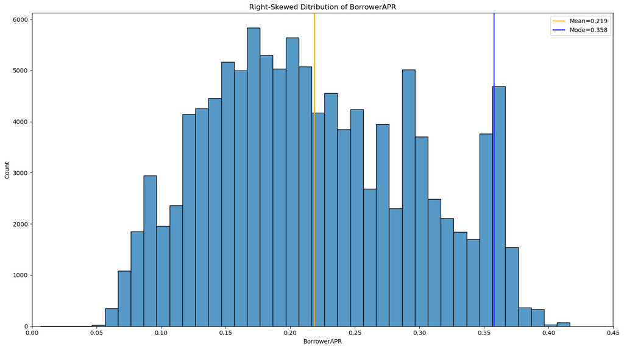

## Regression model for BorrowerAPR vs. LoanOriginalAmount

> We plot a regression of the mean of x-bins superimposed on a scatter plot of 10,000 sample of the cleaned dataset.

> BorrowerAPR and OriginalLoanAmount are negatvely correlated.

> The scatterplot shows a higher density of smaller OriginalLoanAmount values that average higher rates.

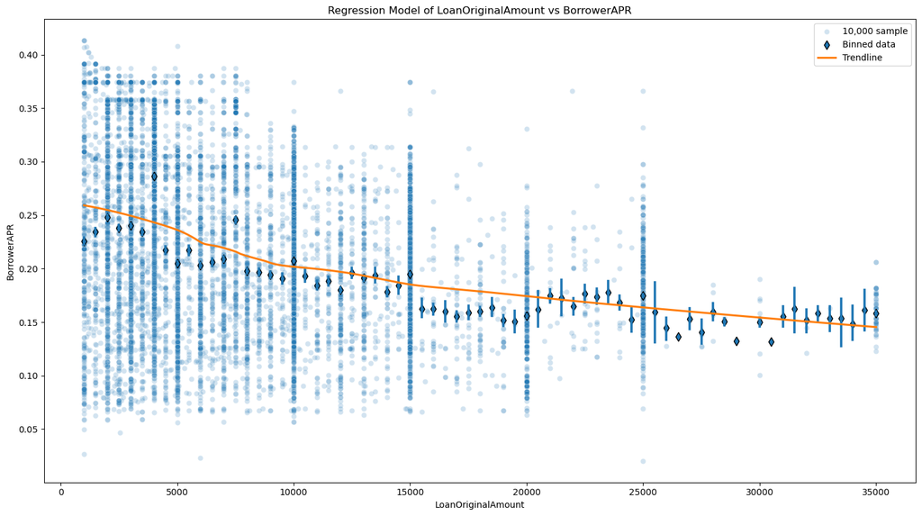

## Correlation matrix for Quantitative Data

> We plot a heatmap of correlation coefficients amoung the quantitative data.

> Similar to OriginalLoanAmount, BorrowerAPR is negatively correlated with CreditScoreRangeUpper and AvailableBankcardCredit.

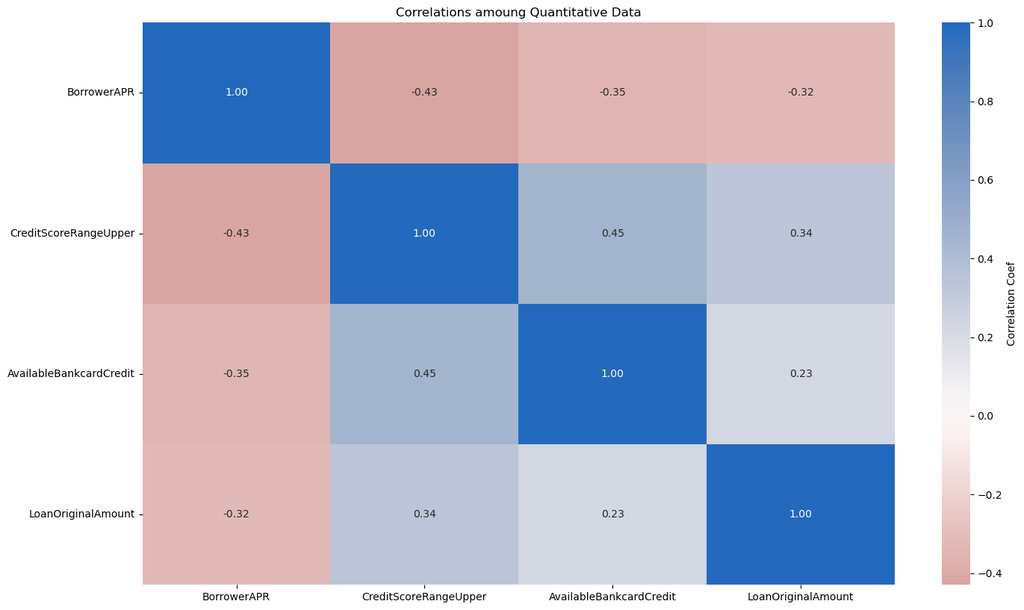

> We plot a pointplot of BorrowerAPR vs IncomeRange, while spliting IncomeVerifiable.

> On average, unverified income is assosiated with high rates of BorrowerAPR.

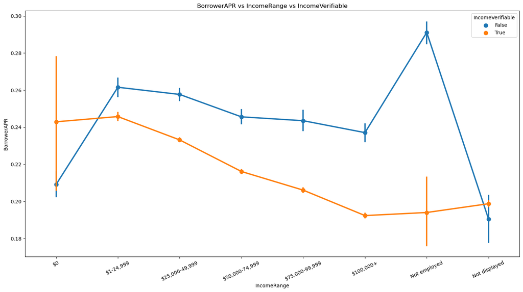

## BorrowerAPR vs EmploymentStatus and IncomeVerifiable

> We plot a facetgrid of BorrowerAPR vs EmploymentStatus and IncomeVerifiable.

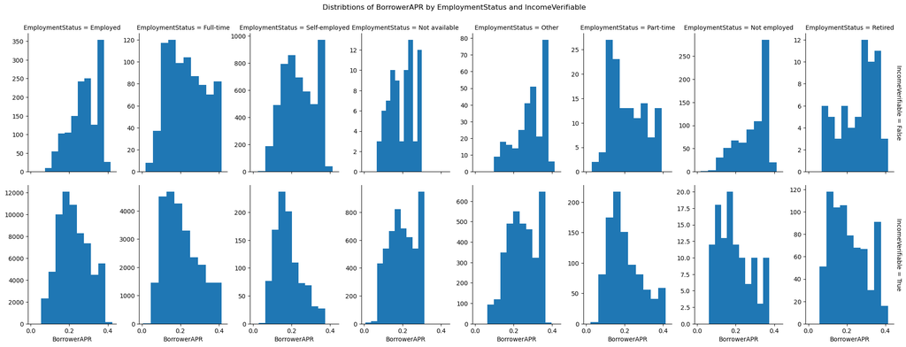